# FDC: Label and coordinate transfer (validation cohort)

Ramon Massoni-Badosa

2023-06-01

# 1 Introduction

Here, we will transfer the label and UMAP coordinates from the discovery cohort to the validation cohort. We will do it one compartment at a time (here, follicular dendritic cells, FDC), so we can validate that the transfer is robust.

Specifically, we will follow these steps for every compartment:

1. Include or update the annotation label for this object.
2. Plot the integrated object split by type (quey/reference) to visualize if discovery and validation cohorts were integrated properly.
3. Transfer label.
4. Transfer UMAP coordinates + visualize
5. Exclude cells with a low annotation probability and/or a high doublet score
6. Visualize heatmap of specific markers to validate that the cluster and annotation holds for the new cohort.

# 2 Pre-processing

## 2.1 Load packages

```r
library(Seurat)
library(tidyverse)
library(caret)
library(class)
library(harmony)
library(here)
library(glue)
library(DT)
```

## 2.2 Source functions

```r
source(here("scRNA-seq/bin/SLOcatoR_functions.R"))
source(here("scRNA-seq/bin/utils.R"))
source(here("scRNA-seq/bin/utils_final_clusters.R"))
color_palette <-  c("#1CFFCE", "#90AD1C", "#C075A6", "#85660D", "#5A5156", "#AA0DFE",
                    "#F8A19F", "#F7E1A0", "#1C8356", "#FEAF16", "#822E1C", "#C4451C",
                    "#1CBE4F", "#325A9B", "#F6222E", "#FE00FA", "#FBE426", "#16FF32",
                    "black",   "#3283FE", "#B00068", "#DEA0FD", "#B10DA1", "#E4E1E3",
                    "#90AD1C", "#FE00FA", "#85660D", "#3B00FB", "#822E1C", "coral2",
                    "#1CFFCE", "#1CBE4F", "#3283FE", "#FBE426", "#F7E1A0", "#325A9B",
                    "#2ED9FF", "#B5EFB5", "#5A5156", "#DEA0FD", "#FEAF16", "#683B79",
                    "#B10DA1", "#1C7F93", "#F8A19F", "dark orange", "#FEAF16", "#FBE426",
                    "Brown")
```

# 3 FDC

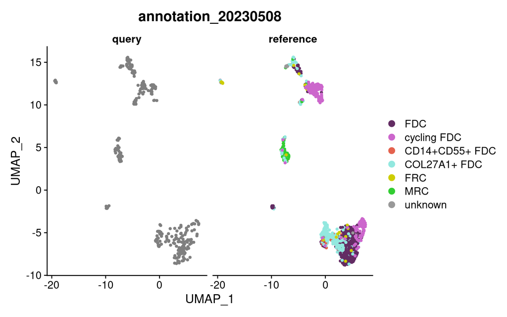

```r
# Read data, clean and include annotation
fdc <- readRDS(here("scRNA-seq/results/R_objects/seurat_objects_revision/4.4-FDC_seurat_object_discovery_validation_cohorts.rds"))
fdc <- updateAnnotation(fdc)
fdc$annotation_20230508 <- fdc$annotation_20220619
fdc$annotation_20230508[fdc$annotation_20230508 == "FDC_multiome"] <- "unannotated"
fdc$annotation_20230508[is.na(fdc$annotation_20230508)] <- "unannotated"
fdc$annotation_20230508 <- factor(
  fdc$annotation_20230508,
  levels = names(colors_20230508[["FDC"]])
)
Idents(fdc) <- "annotation_20230508"
fdc$is_reference <- ifelse(
  fdc$cohort_type == "discovery" & fdc$assay == "3P",
  "reference",
  "query"
)
DimPlot(
  fdc,
  group.by = "annotation_20230508",
  split.by = "is_reference",
  cols = colors_20230508[["FDC"]]
)
```

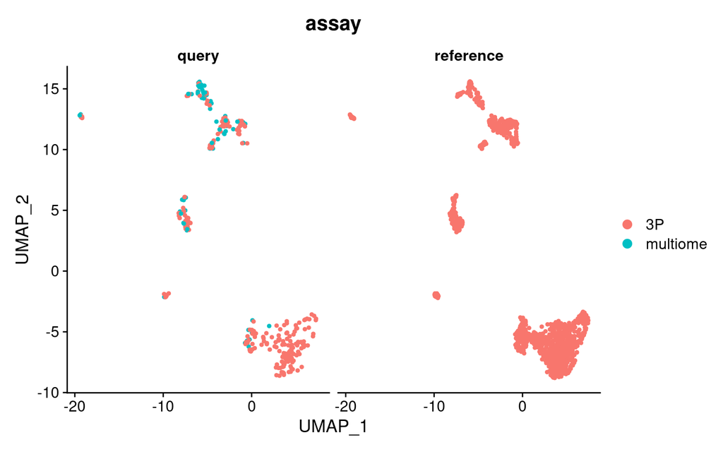

```r
DimPlot(
  fdc,
  group.by = "assay",
  split.by = "is_reference"
)
```

We see that we have too few multiome cells for a proper label transfer. Thus, we will label them as “FDC”, and focus on transering the label from the discovery scRNA-seq dataset to validation scRNA-seq. Let us integrate again this dataset:

```r
Idents(fdc) <- "gem_id"
fdc_rna <- fdc[, fdc$assay == "3P"]
shared_hvg <- find_assay_specific_features(fdc_rna, assay_var = "cohort_type")
print(glue("The number of shared HVG is: {length(shared_hvg)}"))
```

```
## The number of shared HVG is: 2233
```

```r
table(fdc_rna$cohort_type)
```

```
##
##  discovery validation
##       1149        242
```

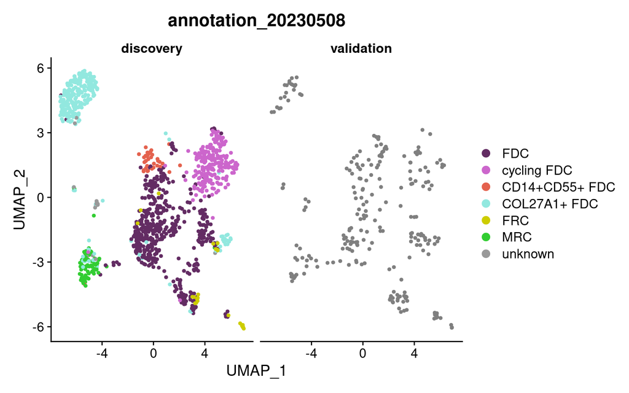

```r
fdc_rna <- integrate_assays(
  fdc_rna,
  assay_var = "cohort_type",
  shared_hvg = shared_hvg
)
fdc_rna <- RunUMAP(fdc_rna, dims = 1:25, reduction = "harmony")
DimPlot(
  fdc_rna,
  group.by = "annotation_20230508",
  split.by = "cohort_type",
  cols = colors_20230508[["FDC"]]
)
```

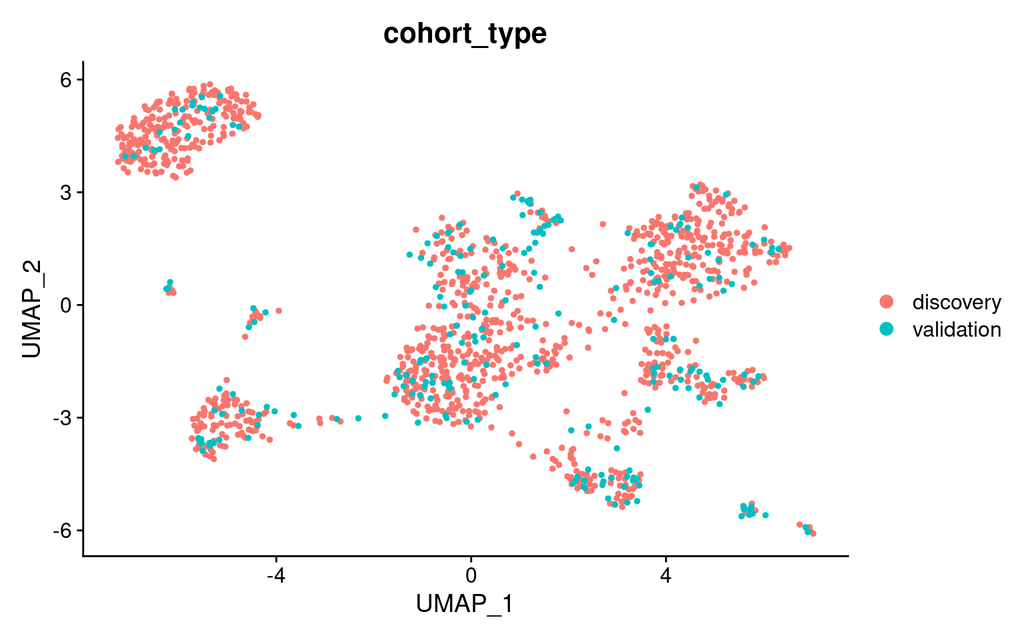

```r
DimPlot(
  fdc_rna,
  group.by = "cohort_type"
)
```

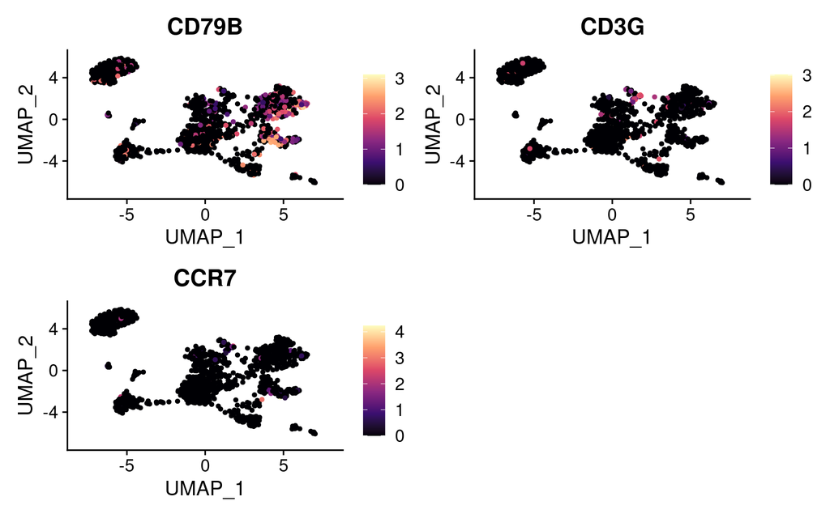

```r
FeaturePlot(fdc_rna, c("CD79B", "CD3G", "CCR7")) &
  scale_color_viridis_c(option = "magma")
```

```r
fdc_rna <- FindNeighbors(fdc_rna, reduction = "harmony", dims = 1:25, k.param = 10)
fdc_rna <- FindClusters(fdc_rna, resolution = 1)
```

```
## Modularity Optimizer version 1.3.0 by Ludo Waltman and Nees Jan van Eck
##
## Number of nodes: 1391
## Number of edges: 24752
##
## Running Louvain algorithm...
## Maximum modularity in 10 random starts: 0.8155
## Number of communities: 14
## Elapsed time: 0 seconds
```

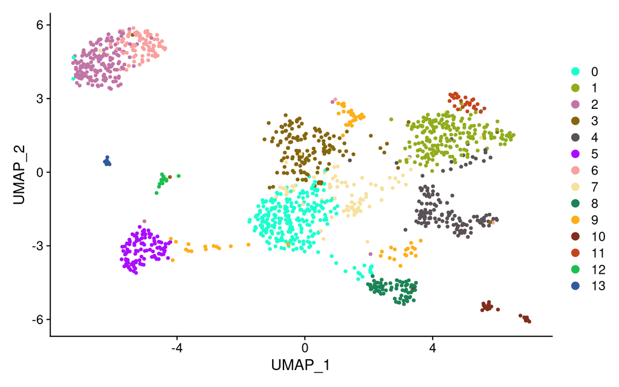

```r
DimPlot(fdc_rna,  cols = color_palette)
```

```r
markers <- map(
  c("1", "4", "9", "11"),
  \(x) FindMarkers(fdc_rna, ident.1 = x, only.pos = TRUE)
)
map(markers, head, 20)
```

```
## [[1]]
##               p_val avg_log2FC pct.1 pct.2    p_val_adj
## STMN1  3.436043e-94  1.1035693 0.897 0.206 1.284324e-89
## HMGB2  2.479102e-93  1.1339950 0.902 0.246 9.266389e-89
## TPX2   1.415472e-89  0.7399232 0.534 0.041 5.290753e-85
## H2AFZ  1.415053e-87  1.0250662 0.961 0.398 5.289185e-83
## HMGB1  5.609825e-87  0.6798359 1.000 0.775 2.096840e-82
## NUSAP1 6.250044e-87  0.8621175 0.613 0.069 2.336141e-82
## CDKN3  2.236716e-85  0.7300049 0.529 0.045 8.360395e-81
## CENPM  2.499217e-84  0.6793046 0.549 0.051 9.341574e-80
## PTTG1  1.037936e-83  0.9067509 0.706 0.110 3.879598e-79
## GCHFR  8.152938e-83  0.7310488 0.578 0.061 3.047405e-78
## HMGA1  9.152286e-83  0.9142465 0.809 0.158 3.420941e-78
## PCLAF  1.790297e-82  0.8206694 0.691 0.100 6.691774e-78
## HMGN2  5.816482e-82  0.9491319 0.980 0.479 2.174085e-77
## UBE2C  1.546119e-80  0.6932428 0.525 0.048 5.779082e-76
## PTMA   4.587407e-79  0.4385662 1.000 0.906 1.714681e-74
## BASP1  3.265081e-78  0.9439684 0.848 0.205 1.220422e-73
## TYMS   2.152335e-77  0.6620078 0.515 0.049 8.044997e-73
## GAPDH  1.007392e-76  0.6355387 1.000 0.755 3.765428e-72
## CORO1A 2.151506e-76  0.9599301 0.936 0.325 8.041899e-72
## CKS2   6.116516e-76  0.7982742 0.627 0.093 2.286231e-71
##
## [[2]]
##                  p_val avg_log2FC pct.1 pct.2    p_val_adj
## HLA-DRA   6.902374e-20  0.5139839 0.869 0.610 2.579969e-15
## CD37      4.561500e-19  0.5840817 0.664 0.329 1.704998e-14
## BANK1     4.526311e-18  0.4874146 0.358 0.102 1.691844e-13
## CD74      6.423760e-17  0.4056918 0.905 0.729 2.401073e-12
## CD52      1.900788e-15  0.5370936 0.672 0.364 7.104766e-11
## HLA-DPB1  1.705218e-14  0.5030657 0.701 0.427 6.373764e-10
## LINC02397 4.891423e-12  0.2745388 0.161 0.033 1.828316e-07
## HLA-DQA1  1.366491e-11  0.4701503 0.526 0.265 5.107672e-07
## MS4A1     1.790158e-10  0.4702103 0.599 0.370 6.691251e-06
## HLA-DMB   4.265026e-10  0.3250142 0.277 0.100 1.594181e-05
## IGHD      9.769813e-10  0.3486601 0.255 0.090 3.651761e-05
## CIITA     1.105020e-09  0.2925624 0.197 0.058 4.130345e-05
## HLA-DRB1  1.447649e-09  0.4450262 0.577 0.360 5.411022e-05
## HLA-DQB1  2.020208e-09  0.4317782 0.431 0.222 7.551135e-05
## LAPTM5    3.104001e-09  0.3967417 0.496 0.272 1.160213e-04
```

[output cut: 36 more lines]

```
## HIST1H1E  1.239088e-10  0.7609590 0.519 0.122 4.631464e-06
## STMN1     1.396459e-10  0.8878124 0.815 0.298 5.219686e-06
## HIST1H3B  1.774490e-09  0.6168737 0.333 0.059 6.632688e-05
## HMGB2     2.120875e-09  0.8398333 0.815 0.333 7.927406e-05
## HMGB1     4.253076e-09  0.5140588 1.000 0.804 1.589715e-04
## NUSAP1    6.094774e-09  0.7526717 0.519 0.141 2.278105e-04
## PCLAF     7.720227e-09  0.8458399 0.556 0.180 2.885667e-04
## GTSE1     2.949308e-08  0.5750876 0.296 0.054 1.102393e-03
## PTMA      1.167811e-07  0.3324894 1.000 0.918 4.365044e-03
## CDKN2D    1.531523e-07  0.5317712 0.296 0.059 5.724527e-03
## TUBA1B    1.533038e-07  0.6514896 0.889 0.542 5.730189e-03
## H2AFZ     1.819860e-07  0.6995298 0.815 0.474 6.802274e-03
## GAPDH     1.852155e-07  0.4517233 0.963 0.787 6.922985e-03
## TCL1A     1.924405e-07  0.7808658 0.556 0.216 7.193041e-03
## RMI2      2.623727e-07  0.4963916 0.296 0.059 9.806965e-03
```

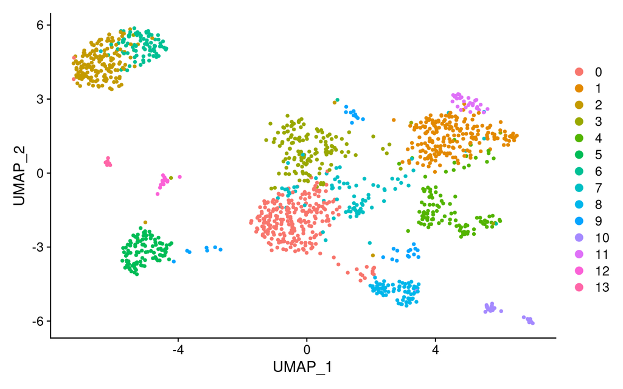

```r
fdc_rna <- fdc_rna[, !(fdc_rna$seurat_clusters %in% c("4", "9") & fdc_rna$cohort_type == "validation")]
DimPlot(fdc_rna)
```

```r
table(fdc_rna$cohort_type)
```

```
##
##  discovery validation
##       1149        185
```

```r
shared_hvg <- find_assay_specific_features(fdc_rna, assay_var = "cohort_type")
print(glue("The number of shared HVG is: {length(shared_hvg)}"))
```

```
## The number of shared HVG is: 2224
```

```r
table(fdc_rna$cohort_type)
```

```
##
##  discovery validation
##       1149        185
```

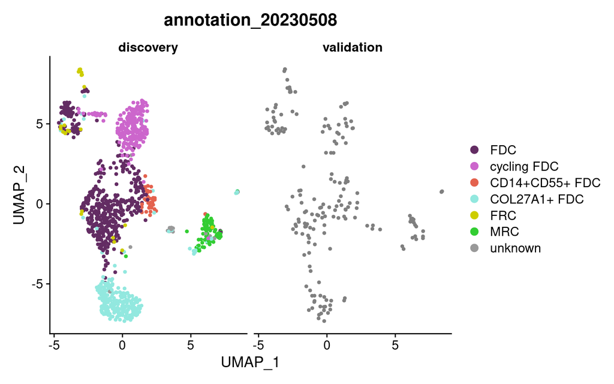

```r
fdc_rna <- integrate_assays(
  fdc_rna,
  assay_var = "cohort_type",
  shared_hvg = shared_hvg
)
fdc_rna <- RunUMAP(fdc_rna, dims = 1:25, reduction = "harmony")
DimPlot(
  fdc_rna,
  group.by = "annotation_20230508",
  split.by = "cohort_type",
  cols = colors_20230508[["FDC"]]
)
```

Now we can transfer the label and UMAP coords

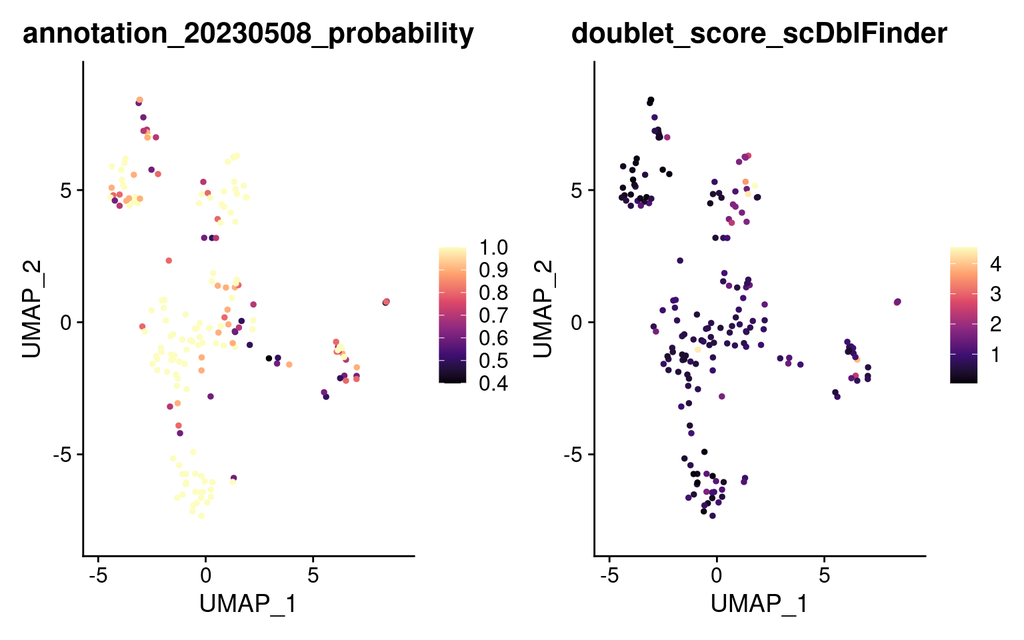

```r
# Split training and test sets
data_sets <- split_training_and_test_sets(
  fdc_rna,
  split_var = "cohort_type",
  referece_label = "discovery",
  query_label = "validation",
  reduction = "harmony",
  n_dims = 25
)


# Transfer label
annotation_query_df <- transfer_label(
  seurat_obj = fdc_rna,
  training_set = data_sets$training_set,
  test_set = data_sets$test_set,
  k = 10,
  response_var = "annotation_20230508"
)

# Transfer UMAP coords
# umap_test_df <- transfer_umap_coords(
#   seurat_obj = fdc_rna,
#   training_set = data_sets$training_set,
#   test_set = data_sets$test_set,
#   umap1_var = "UMAP_1_20220215",
#   umap2_var = "UMAP_2_20220215",
#   k = 15
# )


# Include annotation and UMAP coords in Seurat object
fdc_rna$annotation_20230508[annotation_query_df$query_cells] <- annotation_query_df$annotation
Idents(fdc_rna) <- "annotation_20230508"
fdc_rna$annotation_20230508_probability <- NA
fdc_rna$annotation_20230508_probability[annotation_query_df$query_cells] <- annotation_query_df$annotation_prob
# fdc$UMAP_1_20220215[umap_test_df$query_cells] <- umap_test_df$UMAP1
# fdc$UMAP_2_20220215[umap_test_df$query_cells] <- umap_test_df$UMAP2
p1 <- FeaturePlot(
  fdc_rna[, annotation_query_df$query_cells],
  "annotation_20230508_probability"
) + scale_color_viridis_c(option = "magma")
p2 <- FeaturePlot(
  fdc_rna[, annotation_query_df$query_cells],
  "doublet_score_scDblFinder"
) + scale_color_viridis_c(option = "magma")
p1 | p2
```

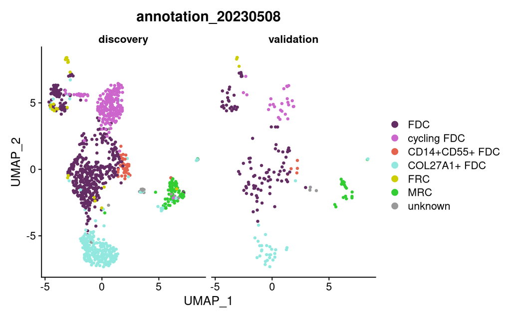

```r
DimPlot(
  fdc_rna,
  group.by = "annotation_20230508",
  split.by = "cohort_type",
  cols = colors_20230508[["FDC"]]
)
```

```r
table(fdc_rna$annotation_20230508_probability)
```

```
##
## 0.4 0.5 0.6 0.7 0.8 0.9   1
##   2   7  14  13  16  21 112
```

Plot dot plot

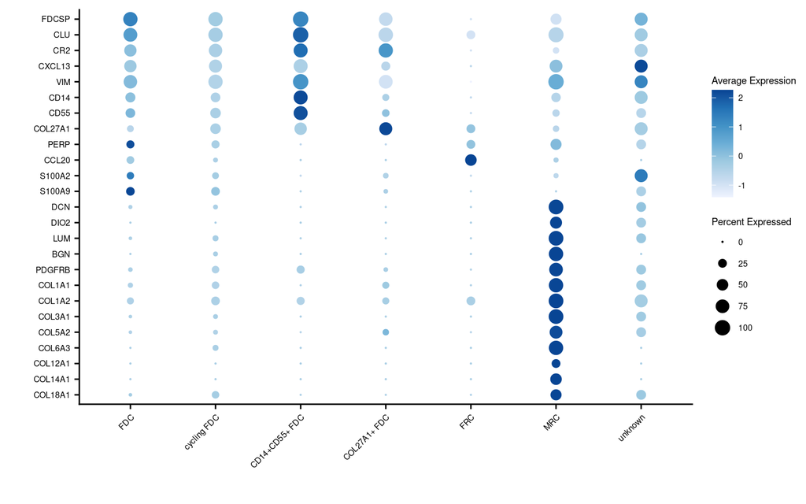

```r
goi_fdc <- list(
  "FDC" = c("FDCSP", "CLU", "CR2", "CXCL13", "VIM"),
  "CD14+CD55+ FDC" = c("CD14", "CD55"),
  "COL27A1+ FDC" = c("COL27A1"),
  "FRC" = c("PERP", "CCL20", "S100A2", "S100A9"),
  "MRC" = c("DCN", "DIO2", "LUM", "BGN", "PDGFRB", "COL1A1", "COL1A2", "COL3A1",
            "COL5A2", "COL6A3", "COL12A1", "COL14A1", "COL18A1")
)
goi_fdc <- unlist(goi_fdc)
names(goi_fdc) <- NULL
dot_plot_fdc <- DotPlot(
  fdc_rna[, fdc_rna$cohort_type == "validation"],
  features = rev(goi_fdc),
  group.by = "annotation_20230508"
)
dot_plot_fdc <- dot_plot_fdc +
  labs(x = "", y = "") +
  scale_size_continuous(
    limits = c(0, 100),
    breaks = c(0, 25, 50, 75, 100),
    range = c(0.1, 4.5)
  ) +
  scale_color_distiller(palette = "Blues", direction = 1) +
  coord_flip() +
  theme(
    axis.text.x = element_text(angle = 45, hjust = 1, vjust = 1, size = 6),
    axis.text.y = element_text(size = 6),
    legend.text = element_text(size = 6),
    legend.title = element_text(size = 7)
  )
dot_plot_fdc
```

# 4 Save

```r
saveRDS(fdc_rna, here("scRNA-seq/results/R_objects/seurat_objects_revision/5.4-FDC_seurat_object_discovery_validation_cohorts_annotation.rds"))
```